# Biology 708, McMaster University

# Intro

## Goals

You should be able to

- read data into R
- understand and control how R represents those data
  - numbers, characters, factors, missing values
- examine the data visually, numerically, textually, etc.

## Representations

Numeric and character types are fairly straightforward, and you rarely have to worry about when and whether R represents things as integers or *floating point*. *Very occasionally* you will need to know that R is limited in its capacity to represent numbers of extremely large or small magnitude, and that floating-point computations are always approximate.

You do need to know about **factors**, and to be aware when your variables are being treated as such.

## Missing values

When you input data, you need to be aware of `NA` (“not available”). Your read function has an option called `na.strings` (base R, `read.*`) or `na` (tidyverse, `read_*`) which you can use to communicate between R and your CSV files, for example specifying that “*” denotes a missing values in a spreadsheet. You need to know that

- `NA==x` is always `NA`
- use `is.na()` to test for `NA` values, `na.omit()` to drop them, and the optional `na.rm` argument in some functions (`mean`, `sum`, `median` …)

## Changing representations

R has a big suite of functions for creating, testing and changing representations. These have names like `factor()`, `as.numeric()` and `is.character()`.

### Factors

Factors are logically variables with a fixed number of categories. In R they are represented as integer variables that have a `levels()` attribute. In other words, each possible value of the factor is given an integer, and the variable carries around the code that allows translation from this integer to its meaning.

This system has advantages:

- You can put the levels in an appropriate order; these govern the order in which the categories are presented when summarizing the data, plotting graphs, or printing the output of statistical models
- R automatically constructs *dummy variables* for regression models
  - You can specify the *contrasts* that R will use when building statistical models (i.e. which levels or comparisons of levels to compare)
- Preserves metadata (e.g. {‘control’, ‘treatment’} variable rather than {0,1})

… and disadvantages:

- It is potentially confusing
  - `as.numeric(f)` is not the same as `as.numeric(as.character(f))`
- Similar variables can have different sets of levels

As a general rule, convert variables to factors *as late as possible*, when you have already fixed typos; combined different data sets; etc..

## Examination

You should think creatively, and early on, about how to check your data. Is it internally consistent? Are there extreme outliers? Are there typos? Are there certain values that really mean something else?

An American Airlines memo about fuel reporting from the 1980s complained of multiple cases of:

- Reported departure fuel greater than aircraft capacity
- Reported departure fuel less than minimum required for trip
- Reported arrival fuel greater than reported departure fuel
- Difference between reported departure fuel and reported arrival fuel not within reasonable min/max bounds

You should think about what you can test, and what you can fix if it’s broken.

Graphical approaches are really useful for data cleaning; we will discuss this more later on.

What R functions do you know that are useful for examination? What are your strategies?

If you’ve decided on a check, embed `stopifnot()` (or `assertthat` package) in your code to throw an error if something unexpected happens

## Manipulation

Even once your data are clean, there can still be a lot of work getting it into a format you want to use. “Data manipulation”, “munging”, or “wrangling” are the terms covering this activity. The RStudio folks have a useful [cheat sheet](https://web.archive.org/web/20190413142317/http://www.rstudio.com/wp-content/uploads/2015/02/data-wrangling-cheatsheet.pdf)

This is a very, very hard, very general problem; everyone’s data problems and requirements are slightly different. But there are recurring themes.

## Specialized data

Some data are in specialized formats, and often already cleaned. We will mention only in passing:

- phylogenetic trees
- sequence data
- maps, spatial data

## Tidy(ing) data

Hadley Wickham has defined a concept of [tidy data](http://www.jstatsoft.org/v59/i10/paper), and has recently introduced the `tidyr` package.

- Each variable is in a column
- Each observation is in a row
- “Long” rather than “wide” form
- Sometimes duplicates data
- Statistical modeling tools and graphical tools (especially the `ggplot2` package) in R work best with long form

### Tools

#### The tidyverse

- `tidyr` package
  - `pivot_longer()`, `pivot_wider()` (reshaping)
  - other data management utilities: `separate()`, `replace_na()`
- `dplyr` package:
  - `mutate()`
  - `select()`
  - `filter()`
  - `group_by()`
  - `summarise()`
  - `arrange()`
  - `*_join()`

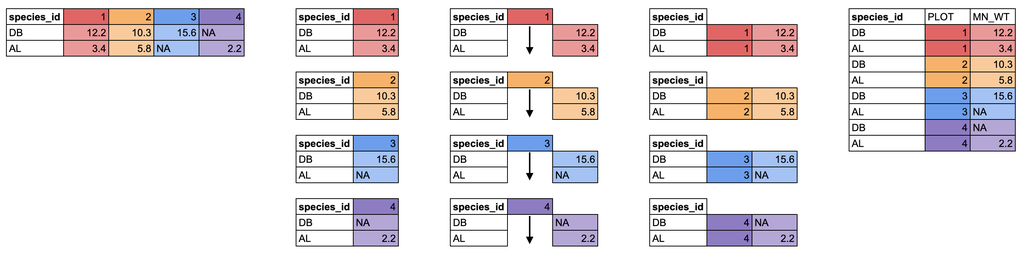

#### base R

- `reshape()`: wide-to-long and vice versa
- `merge()`: join data frames
- `ave()`: compute averages by group
- `subset()`, `[`-indexing: select obs and vars
- `transform()`: modify variables and create new ones
- `aggregate()`: split-apply-summarize
- `split()`, `lapply()`, `do.call(rbind())`: split-apply-combine
- `sort()`